# Project 2: EDA

Jaclyn A Coate

3/23/2020

```r
library(tidyverse)
library(data.table)
library(mice)
library(skimr)
library(corrplot)
library(cowplot)
```

```r
bankraw <- read.csv("https://raw.githubusercontent.com/JaclynCoate/6372_Project_2/master/Data/bank-additional-full.csv", header = TRUE, sep = ";", strip.white = TRUE)
str(bankraw)
```

```
## 'data.frame':    41188 obs. of  21 variables:
##  $ age           : int  56 57 37 40 56 45 59 41 24 25 ...
##  $ job           : Factor w/ 12 levels "admin.","blue-collar",..: 4 8 8 1 8 8 1 2 10 8 ...
##  $ marital       : Factor w/ 4 levels "divorced","married",..: 2 2 2 2 2 2 2 2 3 3 ...
##  $ education     : Factor w/ 8 levels "basic.4y","basic.6y",..: 1 4 4 2 4 3 6 8 6 4 ...
##  $ default       : Factor w/ 3 levels "no","unknown",..: 1 2 1 1 1 2 1 2 1 1 ...
##  $ housing       : Factor w/ 3 levels "no","unknown",..: 1 1 3 1 1 1 1 1 3 3 ...
##  $ loan          : Factor w/ 3 levels "no","unknown",..: 1 1 1 1 3 1 1 1 1 1 ...
##  $ contact       : Factor w/ 2 levels "cellular","telephone": 2 2 2 2 2 2 2 2 2 2 ...
##  $ month         : Factor w/ 10 levels "apr","aug","dec",..: 7 7 7 7 7 7 7 7 7 7 ...
##  $ day_of_week   : Factor w/ 5 levels "fri","mon","thu",..: 2 2 2 2 2 2 2 2 2 2 ...
##  $ duration      : int  261 149 226 151 307 198 139 217 380 50 ...
##  $ campaign      : int  1 1 1 1 1 1 1 1 1 1 ...
##  $ pdays         : int  999 999 999 999 999 999 999 999 999 999 ...
##  $ previous      : int  0 0 0 0 0 0 0 0 0 0 ...
##  $ poutcome      : Factor w/ 3 levels "failure","nonexistent",..: 2 2 2 2 2 2 2 2 2 2 ...
##  $ emp.var.rate  : num  1.1 1.1 1.1 1.1 1.1 1.1 1.1 1.1 1.1 1.1 ...
##  $ cons.price.idx: num  94 94 94 94 94 ...
##  $ cons.conf.idx : num  -36.4 -36.4 -36.4 -36.4 -36.4 -36.4 -36.4 -36.4 -36.4 -36.4 ...
##  $ euribor3m     : num  4.86 4.86 4.86 4.86 4.86 ...
##  $ nr.employed   : num  5191 5191 5191 5191 5191 ...
##  $ y             : Factor w/ 2 levels "no","yes": 1 1 1 1 1 1 1 1 1 1 ...
```

```r
head(bankraw)
```

```
##   age       job marital   education default housing loan   contact month
## 1  56 housemaid married    basic.4y      no      no   no telephone   may
## 2  57  services married high.school unknown      no   no telephone   may
## 3  37  services married high.school      no     yes   no telephone   may
## 4  40    admin. married    basic.6y      no      no   no telephone   may
## 5  56  services married high.school      no      no  yes telephone   may
## 6  45  services married    basic.9y unknown      no   no telephone   may
##   day_of_week duration campaign pdays previous    poutcome emp.var.rate
## 1         mon      261        1   999        0 nonexistent          1.1
## 2         mon      149        1   999        0 nonexistent          1.1
## 3         mon      226        1   999        0 nonexistent          1.1
## 4         mon      151        1   999        0 nonexistent          1.1
## 5         mon      307        1   999        0 nonexistent          1.1
## 6         mon      198        1   999        0 nonexistent          1.1
##   cons.price.idx cons.conf.idx euribor3m nr.employed  y
## 1         93.994         -36.4     4.857        5191 no
## 2         93.994         -36.4     4.857        5191 no
## 3         93.994         -36.4     4.857        5191 no
## 4         93.994         -36.4     4.857        5191 no
## 5         93.994         -36.4     4.857        5191 no
## 6         93.994         -36.4     4.857        5191 no
```

# Question of Interest:

- The data is related with direct marketing campaigns (phone calls) of a Portuguese banking institution. The classification goal is to predict if the client will subscribe a term deposit (variable y).

## EDA to determine narrow down variables to use for the Logistic Regression model

#### Properly naming response variable

```r
setnames(bankraw, "y", "Subscription")
```

#### Removing logically irrelevant variables

- Upon reviewing the available metrics, there are certain variabels that would not make logical sense as a contribution to creating a logisitc regression model

```r
str(bankraw)
```

```
## 'data.frame':    41188 obs. of  21 variables:
##  $ age           : int  56 57 37 40 56 45 59 41 24 25 ...
##  $ job           : Factor w/ 12 levels "admin.","blue-collar",..: 4 8 8 1 8 8 1 2 10 8 ...
##  $ marital       : Factor w/ 4 levels "divorced","married",..: 2 2 2 2 2 2 2 2 3 3 ...
##  $ education     : Factor w/ 8 levels "basic.4y","basic.6y",..: 1 4 4 2 4 3 6 8 6 4 ...
##  $ default       : Factor w/ 3 levels "no","unknown",..: 1 2 1 1 1 2 1 2 1 1 ...
##  $ housing       : Factor w/ 3 levels "no","unknown",..: 1 1 3 1 1 1 1 1 3 3 ...
##  $ loan          : Factor w/ 3 levels "no","unknown",..: 1 1 1 1 3 1 1 1 1 1 ...
##  $ contact       : Factor w/ 2 levels "cellular","telephone": 2 2 2 2 2 2 2 2 2 2 ...
##  $ month         : Factor w/ 10 levels "apr","aug","dec",..: 7 7 7 7 7 7 7 7 7 7 ...
##  $ day_of_week   : Factor w/ 5 levels "fri","mon","thu",..: 2 2 2 2 2 2 2 2 2 2 ...
##  $ duration      : int  261 149 226 151 307 198 139 217 380 50 ...
##  $ campaign      : int  1 1 1 1 1 1 1 1 1 1 ...
##  $ pdays         : int  999 999 999 999 999 999 999 999 999 999 ...
##  $ previous      : int  0 0 0 0 0 0 0 0 0 0 ...
##  $ poutcome      : Factor w/ 3 levels "failure","nonexistent",..: 2 2 2 2 2 2 2 2 2 2 ...
##  $ emp.var.rate  : num  1.1 1.1 1.1 1.1 1.1 1.1 1.1 1.1 1.1 1.1 ...
##  $ cons.price.idx: num  94 94 94 94 94 ...
##  $ cons.conf.idx : num  -36.4 -36.4 -36.4 -36.4 -36.4 -36.4 -36.4 -36.4 -36.4 -36.4 ...
##  $ euribor3m     : num  4.86 4.86 4.86 4.86 4.86 ...
##  $ nr.employed   : num  5191 5191 5191 5191 5191 ...
##  $ Subscription  : Factor w/ 2 levels "no","yes": 1 1 1 1 1 1 1 1 1 1 ...
```

```r
#Dropping logical irrelevant variables: "contact", "campaign", "pdays", "previous"
bankraw2 <- select(bankraw, -c("pdays", "previous", "contact", "campaign"))
head(bankraw2)
```

```
##   age       job marital   education default housing loan month day_of_week
## 1  56 housemaid married    basic.4y      no      no   no   may         mon
## 2  57  services married high.school unknown      no   no   may         mon
## 3  37  services married high.school      no     yes   no   may         mon
## 4  40    admin. married    basic.6y      no      no   no   may         mon
## 5  56  services married high.school      no      no  yes   may         mon
## 6  45  services married    basic.9y unknown      no   no   may         mon
##   duration    poutcome emp.var.rate cons.price.idx cons.conf.idx euribor3m
## 1      261 nonexistent          1.1         93.994         -36.4     4.857
## 2      149 nonexistent          1.1         93.994         -36.4     4.857
## 3      226 nonexistent          1.1         93.994         -36.4     4.857
## 4      151 nonexistent          1.1         93.994         -36.4     4.857
## 5      307 nonexistent          1.1         93.994         -36.4     4.857
## 6      198 nonexistent          1.1         93.994         -36.4     4.857
##   nr.employed Subscription
## 1        5191           no
## 2        5191           no
## 3        5191           no
## 4        5191           no
## 5        5191           no
## 6        5191           no
```

```r
view(bankraw2)
```

#### NA Evaluation and Drop

```r
#Checking for NAs
md.pattern(bankraw2)
```

```
##  /\     /\
## {  `---'  }
## {  O   O  }
## ==>  V <==  No need for mice. This data set is completely observed.
##  \  \|/  /
##   `-----'
```

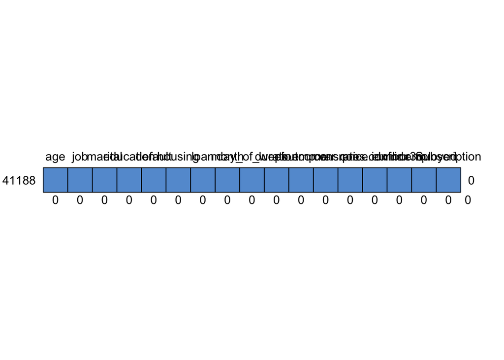

```
##       age job marital education default housing loan month day_of_week
## 41188   1   1       1         1       1       1    1     1           1
##         0   0       0         0       0       0    0     0           0
##       duration poutcome emp.var.rate cons.price.idx cons.conf.idx
## 41188        1        1            1              1             1
##              0        0            0              0             0
##       euribor3m nr.employed Subscription
## 41188         1           1            1 0
##               0           0            0 0
```

```r
#Results show no NAs
```

#### Zero variance variable check - all show variance so remain in model

```r
skim(bankraw2)
```

```
## Skim summary statistics
##  n obs: 41188
##  n variables: 17
##
## ── Variable type:factor ────────────────────────────────────────────────────────
##      variable missing complete     n n_unique
##   day_of_week       0    41188 41188        5
##       default       0    41188 41188        3
##     education       0    41188 41188        8
##       housing       0    41188 41188        3
##           job       0    41188 41188       12
##          loan       0    41188 41188        3
##       marital       0    41188 41188        4
##         month       0    41188 41188       10
##      poutcome       0    41188 41188        3
##  Subscription       0    41188 41188        2
##                                   top_counts ordered
##   thu: 8623, mon: 8514, wed: 8134, tue: 8090   FALSE
##          no: 32588, unk: 8597, yes: 3, NA: 0   FALSE
##  uni: 12168, hig: 9515, bas: 6045, pro: 5243   FALSE
##       yes: 21576, no: 18622, unk: 990, NA: 0   FALSE
##  adm: 10422, blu: 9254, tec: 6743, ser: 3969   FALSE
##        no: 33950, yes: 6248, unk: 990, NA: 0   FALSE
##   mar: 24928, sin: 11568, div: 4612, unk: 80   FALSE
##  may: 13769, jul: 7174, aug: 6178, jun: 5318   FALSE
##      non: 35563, fai: 4252, suc: 1373, NA: 0   FALSE
##                  no: 36548, yes: 4640, NA: 0   FALSE
##
## ── Variable type:integer ───────────────────────────────────────────────────────
##  variable missing complete     n   mean     sd p0 p25 p50 p75 p100
##       age       0    41188 41188  40.02  10.42 17  32  38  47   98
##  duration       0    41188 41188 258.29 259.28  0 102 180 319 4918
##      hist
##  ▂▇▆▃▁▁▁▁
##  ▇▁▁▁▁▁▁▁
##
## ── Variable type:numeric ───────────────────────────────────────────────────────
##        variable missing complete     n     mean    sd      p0     p25
##   cons.conf.idx       0    41188 41188  -40.5    4.63  -50.8   -42.7
##  cons.price.idx       0    41188 41188   93.58   0.58   92.2    93.08
##    emp.var.rate       0    41188 41188    0.082  1.57   -3.4    -1.8
##       euribor3m       0    41188 41188    3.62   1.73    0.63    1.34
##     nr.employed       0    41188 41188 5167.04  72.25 4963.6  5099.1
##      p50     p75    p100     hist
##   -41.8   -36.4   -26.9  ▁▅▆▃▇▁▁▁
##    93.75   93.99   94.77 ▁▁▅▅▁▇▁▂
##     1.1     1.4     1.4  ▁▁▃▁▁▁▁▇
##     4.86    4.96    5.04 ▂▃▁▁▁▁▁▇
##  5191    5228.1  5228.1  ▁▁▁▁▃▁▃▇
```

#### Continuous Variable Review

- First we will review all continuous variables and see whic of those are the most associated with our categorical variable.
  - To accomplish this we will create boxplots of the individual continuous variables compared to the categorical response variable and look for large differences in the summary statistic ranges for the categorical variables.

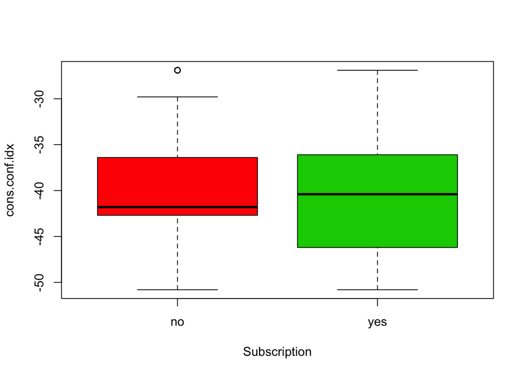

```r
plot(bankraw2$Subscription, bankraw2$cons.conf.idx, xlab = "Subscription", ylab = "cons.conf.idx", title = "Subscription v cons.conf.idx", col=c(82,107))
```

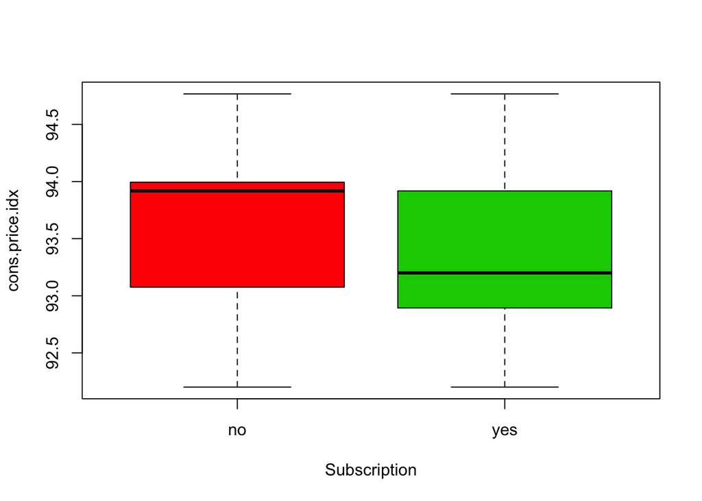

```r
plot(bankraw2$Subscription, bankraw2$cons.price.idx, xlab = "Subscription", ylab = "cons.price.idx", title = "Subscription v cons.price.idx", col=c(82,107))
```

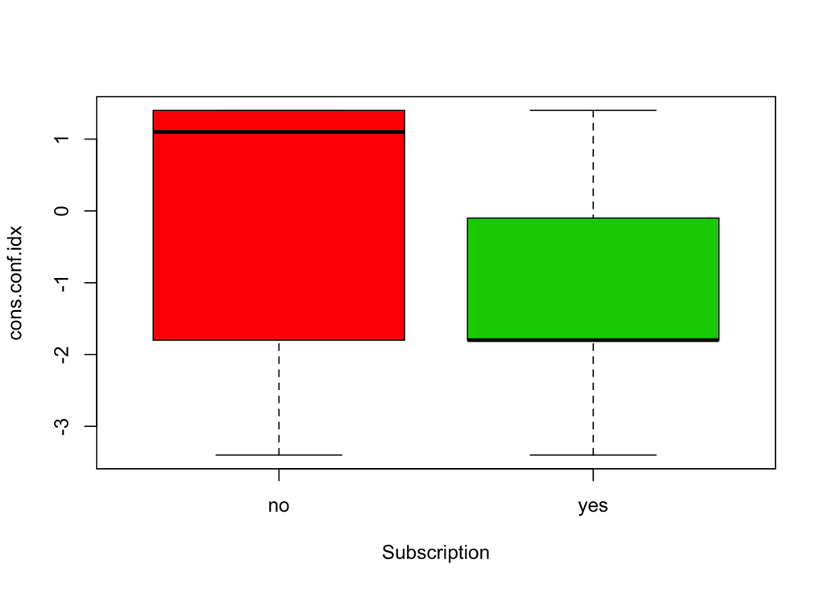

```r
plot(bankraw2$Subscription, bankraw2$emp.var.rate, xlab = "Subscription", ylab = "cons.conf.idx", title = "Subscription v emp.var.rate", col=c(82,107))
```